# Day 2, Session 1: Linear Mixed Effects Regression - Fixed Effects

Dusica Filipovic Durdevic

2026-09-15

## Linear models

- A class of models in which we try to predict variation in some measure (DV) using variation in one or more other variables (IVs)
- To apply them, several conditions need to be satisfied:
  - a linear relationship between the IV and the DV (checked before the analysis, but also during the analysis)
  - independence of measurements, absence of collinearity between predictors (checked before the analysis)
  - homoscedasticity (absence of heteroscedasticity) - uniformity of variance (checked toward the end of the analysis)
  - normality of the residual distribution (checked toward the end of the analysis)
  - absence of influential points (actually the same as the previous point) (checked both before the analysis and toward the end of the analysis)
  - finally, the DV must follow an appropriate distribution (checked before the analysis)
- Different strategies exist for each of these checks, but that’s a topic for a separate class; first we need to cover the basics

## To start, let’s load the packages we need

```r
library(lme4) # to build models
library(lmerTest) # so that p-values are displayed
library(ggplot2) # for plots
library(gridExtra) # for arranging multiple plots
library(patchwork) # for arranging multiple plots
require(see) # for plotting model parameters
library(languageR) # for various things
library(lattice) # for plots
library(parameters) # for plotting model parameters
library(dplyr) # for data wrangling
```

## And let’s load a data frame

```r
df_n=read.table("Dusica.nouns.2004.txt",sep="\t", header = TRUE)
```

- Let’s check the dimensions

```r
dim(df_n)
```

```
## [1] 4320   19
```

## A quick look at the data

```r
head(df_n)
```

```
##   Trial_order Participant Participant_number Trial_name Trial_number Error_code
## 1          14          s1                 24         t1            1          C
## 2         178          s1                 24         t2            2          C
## 3          61          s1                 24         t3            3          C
## 4          55          s1                 24         t4            4          C
## 5          69          s1                 24         t5            5          C
## 6          63          s1                 24         t6            6          C
##   Accuracy  RT PrevRT Lexicality NoS PolyLevelCategory Frequency FreCategory
## 1        1 872    581       word   1          lowPolys       302       LowFr
## 2        1 541    470       word   1          lowPolys       320       LowFr
## 3        1 721    681       word   1          lowPolys       391       LowFr
## 4        1 570    530       word   1          lowPolys       414        HiFr
## 5        1 581    541       word   1          lowPolys       424        HiFr
## 6        1 501    491       word   1          lowPolys       448        HiFr
##     Word Length PartSpeed PartAccuracy PartSpeedCategory
## 1  [APAT      5  672.2514    0.9944444              slow
## 2 MR@NJA      6  672.2514    0.9944444              slow
## 3  CESTA      5  672.2514    0.9944444              slow
## 4 ^E@NJA      6  672.2514    0.9944444              slow
## 5 GRANJE      6  672.2514    0.9944444              slow
## 6  DE^AK      5  672.2514    0.9944444              slow
```

## Let’s take a look at the data’s structure

```r
str(df_n)
```

```
## 'data.frame':    4320 obs. of  19 variables:
##  $ Trial_order       : int  14 178 61 55 69 63 62 76 172 122 ...
##  $ Participant       : chr  "s1" "s1" "s1" "s1" ...
##  $ Participant_number: int  24 24 24 24 24 24 24 24 24 24 ...
##  $ Trial_name        : chr  "t1" "t2" "t3" "t4" ...
##  $ Trial_number      : int  1 2 3 4 5 6 7 8 9 10 ...
##  $ Error_code        : chr  "C" "C" "C" "C" ...
##  $ Accuracy          : int  1 1 1 1 1 1 1 1 1 1 ...
##  $ RT                : int  872 541 721 570 581 501 491 501 550 591 ...
##  $ PrevRT            : chr  "581" "470" "681" "530" ...
##  $ Lexicality        : chr  "word" "word" "word" "word" ...
##  $ NoS               : int  1 1 1 1 1 1 1 1 1 1 ...
##  $ PolyLevelCategory : chr  "lowPolys" "lowPolys" "lowPolys" "lowPolys" ...
##  $ Frequency         : int  302 320 391 414 424 448 453 720 786 1085 ...
##  $ FreCategory       : chr  "LowFr" "LowFr" "LowFr" "HiFr" ...
##  $ Word              : chr  "[APAT" "MR@NJA" "CESTA" "^E@NJA" ...
##  $ Length            : int  5 6 5 6 6 5 5 5 5 5 ...
##  $ PartSpeed         : num  672 672 672 672 672 ...
##  $ PartAccuracy      : num  0.994 0.994 0.994 0.994 0.994 ...
##  $ PartSpeedCategory : chr  "slow" "slow" "slow" "slow" ...
```

## Let’s take care of the data types

```r
df_n = df_n %>%
  mutate(
    Participant       = as.factor(Participant),
    Lexicality        = as.factor(Lexicality),
    PolyLevelCategory = as.factor(PolyLevelCategory),
    Word              = as.factor(Word),
    FreCategory       = as.factor(FreCategory),
    PartSpeedCategory = as.factor(PartSpeedCategory)
  )
```

## Check by-participant accuracy

- Create a variable that contains average accuracy per participant

```r
df_n = df_n %>%
  group_by(Participant) %>%
  mutate(PartAcc = mean(Accuracy, na.rm = TRUE)) %>%
  ungroup()

sort(unique(df_n$PartAcc))
```

```
##  [1] 0.9111111 0.9388889 0.9444444 0.9500000 0.9555556 0.9611111 0.9666667
##  [8] 0.9722222 0.9777778 0.9833333 0.9888889 0.9944444
```

- Exclude participants with more than 25% errors – keep only those with accuracy 75% or higher

```r
before_p = n_distinct(df_n$Participant)

df_n = df_n %>% filter(PartAcc >= 0.75)

after_p = n_distinct(df_n$Participant)

NumExcludedPart = before_p - after_p
NumExcludedPart
```

```
## [1] 0
```

## Check by-item accuracy

- Create a variable that contains average accuracy per item (word)

```r
df_n = df_n %>%
  group_by(Word) %>%
  mutate(ItemAcc = mean(Accuracy, na.rm = TRUE)) %>%
  ungroup()

sort(unique(df_n$ItemAcc))
```

```
## [1] 0.6666667 0.7500000 0.7916667 0.8333333 0.8750000 0.9166667 0.9583333
## [8] 1.0000000
```

- Exclude items with more than 25% errors – keep only those with accuracy 75% or higher

```r
before_i = n_distinct(df_n$Word)

df_n = df_n %>% filter(ItemAcc >= 0.75)

after_i = n_distinct(df_n$Word)

NumExcludedItems = before_i - after_i
NumExcludedItems
```

```
## [1] 1
```

## Let’s keep only words and correct responses in the data frame

- only words

```r
df_n = df_n %>% filter(Lexicality == "word")
```

- only correct responses

```r
df_n = df_n %>% filter(Error_code == "C")
```

## Let’s transform word frequency, since we know it has a log relationship with RT (Recall the linearity assumption)

- Later we will also formally check whether the relationship is linear but more on that later

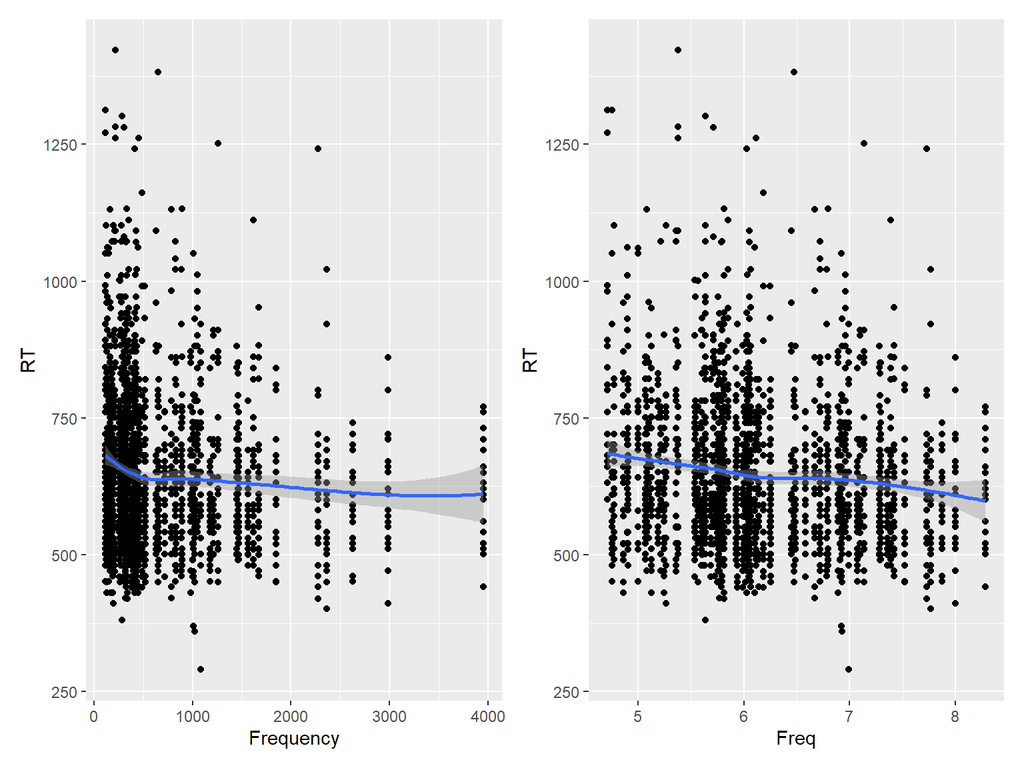

```r
df_n = df_n %>%
  mutate(Freq = log(as.numeric(Frequency)))

library(patchwork)
g1 = ggplot(df_n, aes(x=Frequency, y=RT)) +
  geom_point() +
  geom_smooth(method = "loess", se = TRUE)

g2 = ggplot(df_n, aes(x=Freq, y=RT)) +
  geom_point() +
  geom_smooth(method = "loess", se = TRUE)

g1 | g2
```

## In addition, continuous predictors should be centered at zero

- We’ll see later why (when we discuss the interpretability of the intercept) and it’s even better to normalize the values:

```r
df_n = df_n %>%
  mutate(
    logFreq = Freq,
    Freq_z  = as.numeric(scale(Freq))
  )
```

- Let’s see what we did to Freq_z:

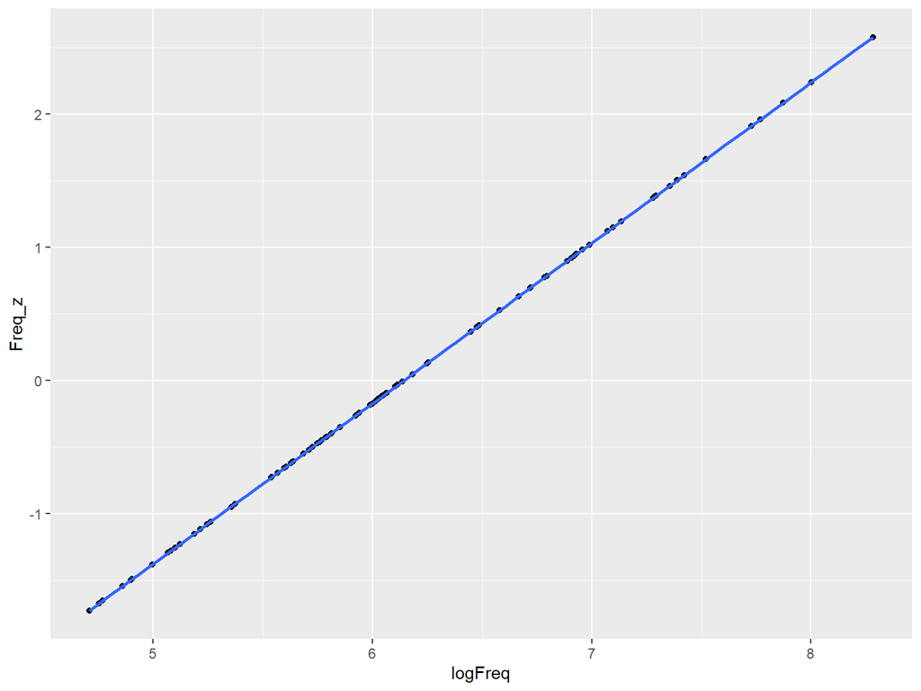

```r
ggplot(df_n, aes(x=logFreq, y=Freq_z)) +
  geom_point() +
  geom_smooth(method = "loess", se = TRUE)
```

```r
mean(df_n$logFreq)
```

```
## [1] 6.144891
```

```r
exp(mean(df_n$logFreq))
```

```
## [1] 466.3287
```

```r
round(mean(df_n$Freq_z),5)
```

```
## [1] 0
```

## Let’s also scale the number of senses

```r
df_n = df_n %>%
  mutate(
    NoS   = as.numeric(NoS),
    NoS_z = as.numeric(scale(NoS))
  )
```

## Let’s check whether the DV (RT) is normally distributed

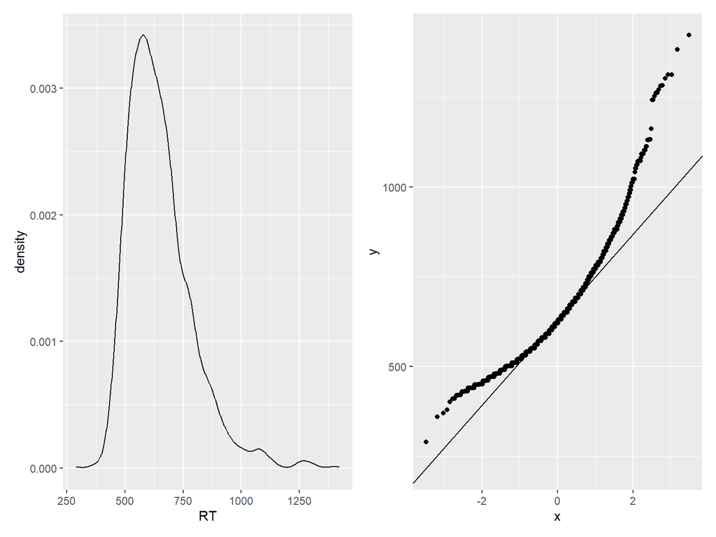

```r
g1 = ggplot(df_n, aes(RT)) + geom_density()
g2 = ggplot(df_n, aes(sample=RT)) +
  stat_qq() + stat_qq_line()

g1+g2
```

- Various transformations exist
- For now we’ll apply a logarithmic transformation to RT

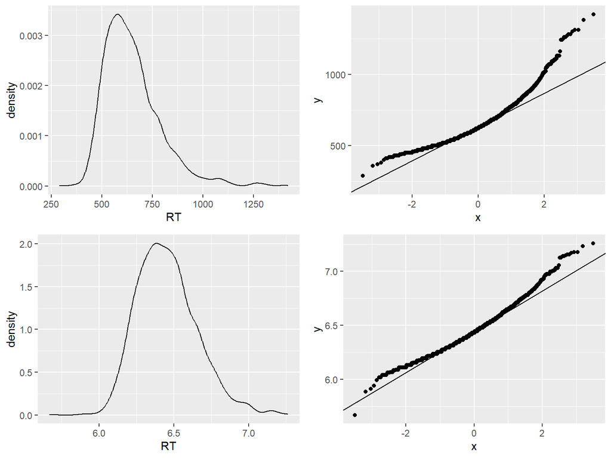

```r
df_n = df_n %>%
  mutate(RT = log(RT))


g3 = ggplot(df_n, aes(RT)) + geom_density()
g4 = ggplot(df_n, aes(sample=RT)) +
  stat_qq() + stat_qq_line()


grid.arrange(g1,g2,g3,g4, layout_matrix = rbind(c(1,2),
                                                c(3,4)))
```

## The next important condition is independence of measurements

- Let’s look at what the situation is in our data frame

```r
xtabs(~ Participant + Word, data = df_n)
```

```
##            Word
## Participant [AMAT [APAT [KOLA [KONJA ^E@NJA APNIL APRIL BA[TA BANTA BLAGO BLATO
##         s1      0     1     1      0      1     0     1     1     0     1     1
##         s10     0     1     1      0      1     0     1     1     0     1     1
##         s11     0     1     1      0      1     0     1     1     0     1     1
##         s12     0     1     1      0      1     0     1     1     0     1     1
##         s13     0     1     1      0      1     0     1     1     0     1     1
##         s14     0     0     1      0      1     0     1     1     0     1     1
##         s15     0     1     1      0      1     0     1     1     0     1     1
##         s16     0     1     1      0      1     0     1     1     0     1     1
##         s17     0     1     1      0      1     0     1     1     0     1     1
##         s18     0     1     1      0      1     0     1     1     0     1     1
##         s19     0     1     1      0      1     0     1     1     0     1     1
##         s2      0     1     1      0      1     0     1     1     0     1     1
##         s20     0     1     1      0      1     0     1     1     0     1     1
##         s21     0     0     1      0      1     0     1     1     0     1     1
##         s22     0     1     1      0      1     0     1     1     0     1     1
##         s23     0     1     1      0      1     0     1     1     0     1     1
##         s24     0     0     1      0      1     0     1     1     0     1     1
##         s3      0     1     1      0      1     0     1     1     0     1     1
##         s4      0     0     1      0      1     0     1     1     0     1     1
##         s5      0     1     1      0      1     0     1     1     0     1     1
##         s6      0     1     1      0      1     0     1     1     0     1     1
##         s7      0     1     1      0      1     0     1     1     0     1     1
##         s8      0     1     1      0      1     0     1     1     0     1     1
##         s9      0     1     1      0      1     0     1     1     0     1     1
##            Word
## Participant BORBA BORLA CESKA CESTA CVE]E DA@NJA DE^AK DINAR DINAT DRI^A EKIPA
##         s1      1     0     0     0     1      0     1     1     0     0     1
##         s10     1     0     0     0     1      0     1     1     0     0     1
##         s11     1     0     0     0     1      0     1     1     0     0     1
##         s12     1     0     0     0     1      0     1     1     0     0     1
##         s13     1     0     0     0     1      0     1     1     0     0     1
##         s14     1     0     0     0     1      0     1     1     0     0     1
##         s15     1     0     0     0     1      0     1     1     0     0     1
##         s16     1     0     0     0     1      0     1     1     0     0     1
##         s17     1     0     0     0     1      0     1     1     0     0     1
##         s18     1     0     0     0     1      0     1     1     0     0     1
##         s19     1     0     0     0     1      0     1     1     0     0     1
##         s2      1     0     0     0     1      0     1     1     0     0     0
```

[output cut: 387 more lines]

```
##         s18     0      1     0     1     0     1
##         s19     0      1     0     1     0     1
##         s2      0      1     0     1     0     1
##         s20     0      1     0     1     0     1
##         s21     0      1     0     1     0     1
##         s22     0      1     0     1     0     1
##         s23     0      1     0     1     0     1
##         s24     0      1     0     1     0     1
##         s3      0      1     0     1     0     1
##         s4      0      1     0     1     0     1
##         s5      0      1     0     1     0     1
##         s6      0      1     0     1     0     1
##         s7      0      1     0     1     0     1
##         s8      0      1     0     1     0     1
##         s9      0      1     0     1     0     1
```

## We do not have independence of measurements!

- We see that every Participant saw every word (and pseudowords too, but we removed that data, hence the zeros for pseudowords)
- This means we do not have independent measurements!
- How is this problem resolved?

## THE TRADITIONAL WAY

- Running two separate analyses
- Averaging the DV values across all words for individual Participants, running a by-Participant analysis (the so-called F1 test) in which Participants are treated as a source of random effects
- Averaging the DV values across all Participants for individual words (the so-called F2 test)

## Let’s start by doing that

- To compute averages by word, we use the summarise() function
  - The first argument is the name of the new variable
  - The second argument is the action we’re applying
  - The third argument is the variable we want to average

```r
nouns = df_n %>%
  group_by(Word) %>%
  summarise(MeanRT = mean(RT, na.rm = TRUE))
```

- Now let’s take the columns we need from the large data frame

```r
nouns_by_item = df_n %>%
  select(Word, Length, Freq_z, FreCategory, NoS_z, PolyLevelCategory, PartSpeed)
```

```r
nouns_by_item = nouns_by_item %>% distinct()
```

- Finally, let’s join the two new data frames, using the Word column as the key for joining

```r
nouns_by_item = nouns_by_item %>%
  left_join(nouns, by = "Word")
```

## Now we have a data frame with average reaction times for words

```r
head(nouns_by_item)
```

```
## # A tibble: 6 × 8
##   Word   Length  Freq_z FreCategory NoS_z PolyLevelCategory PartSpeed MeanRT
##   <fct>   <int>   <dbl> <fct>       <dbl> <fct>                 <dbl>  <dbl>
## 1 [APAT       5 -0.524  LowFr       -1.58 lowPolys               672.   6.65
## 2 MR@NJA      6 -0.454  LowFr       -1.58 lowPolys               672.   6.43
## 3 ^E@NJA      6 -0.143  HiFr        -1.58 lowPolys               672.   6.57
## 4 GRANJE      6 -0.115  HiFr        -1.58 lowPolys               672.   6.63
## 5 DE^AK       5 -0.0483 HiFr        -1.58 lowPolys               672.   6.40
## 6 APRIL       5 -0.0349 HiFr        -1.58 lowPolys               672.   6.43
```

## INTERPRETING COEFFICIENTS IN A LINEAR MODEL

- Given that the interpretation of coefficients for fixed effects is identical in lm and lmer, and that it can be complicated, we’ll deal with it first

## THE CASE OF A SINGLE CONTINUOUS PREDICTOR

- Let’s look at the relationship between word frequency and recognition time:

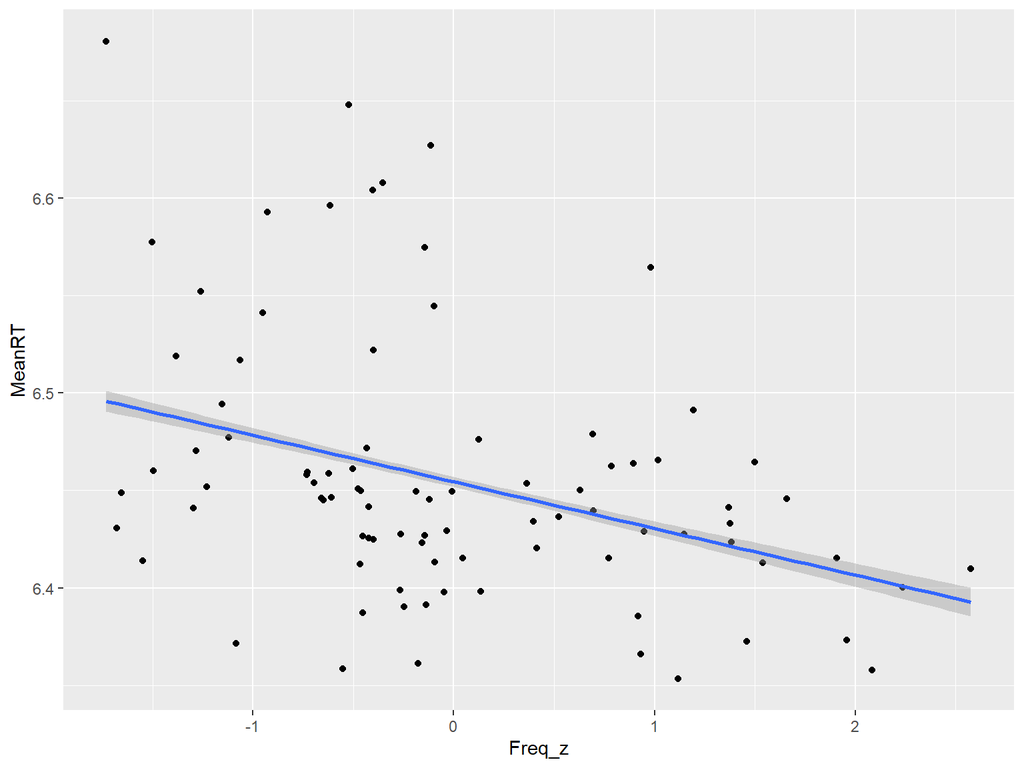

```r
ggplot(nouns_by_item, aes(x=Freq_z, y=MeanRT)) +
  geom_point() +
  geom_smooth(method = "lm", se = TRUE)
```

## Every linear model consists of

- Something we understand, something we know about (predictors), and something we don’t understand, something we know nothing about (error)
  - DV ~ IV + error
- For the part we understand (the effect of the predictor), the model computes an intercept and a slope, and what we don’t understand becomes the residuals:
  - DV ~ Intercept + slope * IV + residual
- To build a linear model in R, we use this notation:

```r
lm1 = lm(MeanRT ~ Freq_z, data = nouns_by_item)
```

## We’ve built an object that contains various pieces of information

- We get what we need using the summary() command

```r
summary(lm1)
```

```
##
## Call:
## lm(formula = MeanRT ~ Freq_z, data = nouns_by_item)
##
## Residuals:
##      Min       1Q   Median       3Q      Max
## -0.10911 -0.03899 -0.01199  0.02465  0.18457
##
## Coefficients:
##              Estimate Std. Error t value Pr(>|t|)
## (Intercept)  6.454413   0.001351  4778.6   <2e-16 ***
## Freq_z      -0.023908   0.001351   -17.7   <2e-16 ***
## ---
## Signif. codes:  0 '***' 0.001 '**' 0.01 '*' 0.05 '.' 0.1 ' ' 1
##
## Residual standard error: 0.06159 on 2077 degrees of freedom
## Multiple R-squared:  0.131,  Adjusted R-squared:  0.1306
## F-statistic: 313.2 on 1 and 2077 DF,  p-value: < 2.2e-16
```

## The lm1 object (among other things) contains the coefficients: intercept and slope

- To get just the coefficients:

```r
coef(lm1)
```

```
## (Intercept)      Freq_z
##  6.45441293 -0.02390782
```

- The intercept tells us the reaction time for Freq_z = 0
- Since a frequency of zero doesn’t make sense, we centered the data so that the intercept would be interpretable.
- So the intercept tells us the time it takes to recognize a word that has the average frequency (of the words in the experiment).
- The slope tells us how much the reaction time changes when we move one unit along the x-axis.

## An important element of a linear model is the so-called model matrix

```r
head(model.matrix(lm1), n=10)
```

```
##    (Intercept)      Freq_z
## 1            1 -0.52362420
## 2            1 -0.45384925
## 3            1 -0.14345105
## 4            1 -0.11468550
## 5            1 -0.04832639
## 6            1 -0.03494978
## 7            1  0.52349957
## 8            1  0.62920404
## 9            1  1.01774083
## 10           1 -0.73223894
```

- The prediction for each word is calculated by applying the equation:

```r
model.matrix(lm1)
```

```
##      (Intercept)       Freq_z
## 1              1 -0.523624198
## 2              1 -0.453849253
## 3              1 -0.143451049
## 4              1 -0.114685498
## 5              1 -0.048326386
## 6              1 -0.034949785
## 7              1  0.523499574
## 8              1  0.629204041
## 9              1  1.017740831
## 10             1 -0.732238939
## 11             1 -0.649720219
## 12             1 -0.465201481
## 13             1 -0.453849253
## 14             1 -0.265913605
```

[output cut: 2067 more lines]

## THE CASE OF A SINGLE CATEGORICAL PREDICTOR

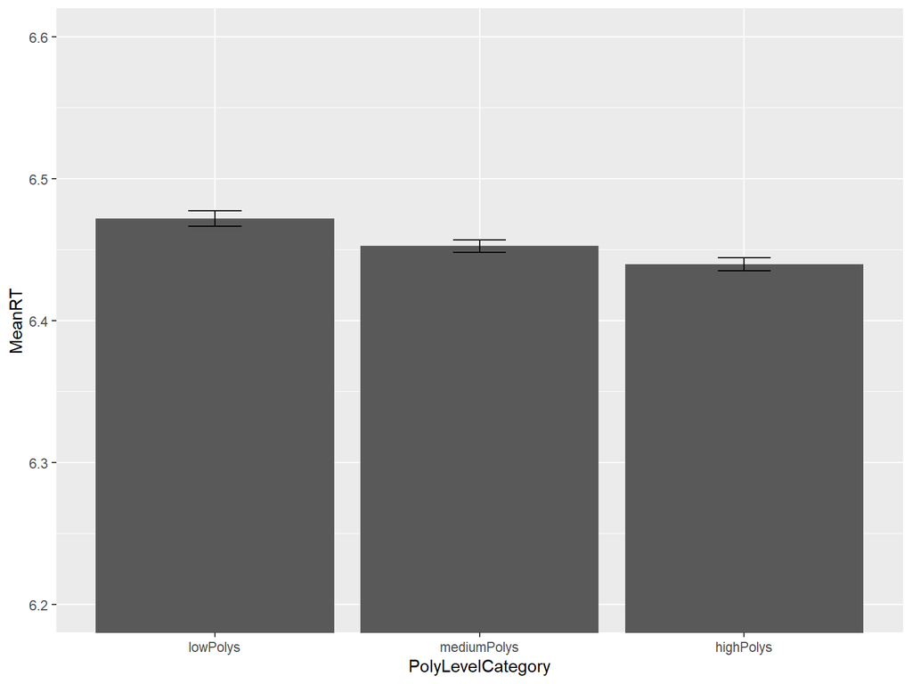

```r
ggplot(nouns_by_item, aes(x=PolyLevelCategory, y=MeanRT)) +
  scale_x_discrete(limits=c("lowPolys", "mediumPolys", "highPolys")) +
  coord_cartesian(ylim = c(6.2, 6.6)) +
  stat_summary(fun = mean, geom = "bar", position = "dodge") +
  stat_summary(fun.data = mean_cl_normal, geom = "errorbar", position =    position_dodge(width = 0.90), width = 0.2)
```

## Let’s build a linear model:

```r
lm2 = lm(MeanRT ~ PolyLevelCategory, data = nouns_by_item)

summary(lm2)
```

```
##
## Call:
## lm(formula = MeanRT ~ PolyLevelCategory, data = nouns_by_item)
##
## Residuals:
##      Min       1Q   Median       3Q      Max
## -0.09478 -0.04428 -0.01097  0.02362  0.24066
##
## Coefficients:
##                              Estimate Std. Error  t value Pr(>|t|)
## (Intercept)                  6.439687   0.002442 2636.623  < 2e-16 ***
## PolyLevelCategorylowPolys    0.032165   0.003494    9.207  < 2e-16 ***
## PolyLevelCategorymediumPolys 0.012784   0.003453    3.702 0.000219 ***
## ---
## Signif. codes:  0 '***' 0.001 '**' 0.01 '*' 0.05 '.' 0.1 ' ' 1
##
## Residual standard error: 0.06476 on 2076 degrees of freedom
## Multiple R-squared:  0.03965,    Adjusted R-squared:  0.03873
## F-statistic: 42.86 on 2 and 2076 DF,  p-value: < 2.2e-16
```

## The relationship between category averages and coefficients

- Let’s compute the averages for the three categories of the PolyLevelCategory (Polysemy) variable

```r
tapply(nouns_by_item$MeanRT, nouns_by_item$PolyLevelCategory, mean)
```

```
##   highPolys    lowPolys mediumPolys
##    6.439687    6.471852    6.452471
```

- Let’s look at just the coefficients:

```r
coef(lm2)
```

```
##                  (Intercept)    PolyLevelCategorylowPolys
##                   6.43968731                   0.03216490
## PolyLevelCategorymediumPolys
##                   0.01278375
```

- The intercept actually represents the average for the high polysemy group.
- The coefficient for low polysemy tells us by how much we need to increase the intercept value to get the average for the low polysemy group.

## We can verify this

- coefficients

```r
coef(lm2)
```

```
##                  (Intercept)    PolyLevelCategorylowPolys
##                   6.43968731                   0.03216490
## PolyLevelCategorymediumPolys
##                   0.01278375
```

- group averages

```r
lowPolys = mean(nouns_by_item[nouns_by_item$PolyLevelCategory=="lowPolys",]$MeanRT)

mediumPolys = mean(nouns_by_item[nouns_by_item$PolyLevelCategory=="mediumPolys",]$MeanRT)

highPolys = mean(nouns_by_item[nouns_by_item$PolyLevelCategory=="highPolys",]$MeanRT)
```

```r
## to get the first coefficient
lowPolys - highPolys
```

```
## [1] 0.0321649
```

```r
## to get the second coefficient
mediumPolys - highPolys
```

```
## [1] 0.01278375
```

- i.e.:

```r
## to get the average for low polysemy
highPolys + 0.03216490
```

```
## [1] 6.471852
```

```r
## to get the average for low polysemy
highPolys + 0.01278375
```

```
## [1] 6.452471
```

## R’s default coding is so-called treatment coding, or dummy coding

- This coding means that the first level of the variable is assigned the value 0, which maps this level onto the intercept.
- The next level gets the value 1

  ```
  + More precisely, for each new level of a categorical variable, a new variable is created
    that has the value 1 at that level and zero everywhere else.
  ```

- In this case, high polysemy was assigned the first level, because it comes first alphabetically

```r
head(model.matrix(lm2), n=10)
```

```
##    (Intercept) PolyLevelCategorylowPolys PolyLevelCategorymediumPolys
## 1            1                         1                            0
## 2            1                         1                            0
## 3            1                         1                            0
## 4            1                         1                            0
## 5            1                         1                            0
## 6            1                         1                            0
## 7            1                         1                            0
## 8            1                         1                            0
## 9            1                         1                            0
## 10           1                         1                            0
```

```r
model.matrix(lm2)
```

```
##      (Intercept) PolyLevelCategorylowPolys PolyLevelCategorymediumPolys
## 1              1                         1                            0
## 2              1                         1                            0
## 3              1                         1                            0
## 4              1                         1                            0
## 5              1                         1                            0
## 6              1                         1                            0
## 7              1                         1                            0
## 8              1                         1                            0
## 9              1                         1                            0
## 10             1                         1                            0
## 11             1                         1                            0
## 12             1                         1                            0
## 13             1                         1                            0
## 14             1                         1                            0
```

[output cut: 2070 more lines]

```r
contrasts(nouns_by_item$PolyLevelCategory)
```

```
##             lowPolys mediumPolys
## highPolys          0           0
## lowPolys           1           0
## mediumPolys        0           1
```

## If we want to map the intercept onto a different level, we use relevel

```r
nouns_by_item$PolyLevelCategory <- relevel(nouns_by_item$PolyLevelCategory,
                                           ref = "mediumPolys")
```

- and then refit the model

```r
lm2a = lm(MeanRT ~ PolyLevelCategory, data = nouns_by_item)
coef(lm2a)
```

```
##                (Intercept) PolyLevelCategoryhighPolys
##                 6.45247105                -0.01278375
##  PolyLevelCategorylowPolys
##                 0.01938116
```

- now the intercept is mapped onto medium polysemy and equals the average for this group of words
- we get the average for the high polysemy group by adding the coefficient for high polysemy to the intercept value

```r
6.45247105 -0.01278375
```

```
## [1] 6.439687
```

- we get the average for the low polysemy group by adding the coefficient for low polysemy to the intercept value

```r
6.45247105 + 0.01938116
```

```
## [1] 6.471852
```

- for anyone who doesn’t believe it, you can compare:

```r
tapply(nouns_by_item$MeanRT, nouns_by_item$PolyLevelCategory, mean)
```

```
## mediumPolys   highPolys    lowPolys
##    6.452471    6.439687    6.471852
```

## Let’s summarize the meaning of the intercept and the slope:

- The intercept is always mapped onto the zero level for all predictors.
- If it’s a continuous predictor, that’s the value zero

  ```
  + in that case it's best to center the data at zero,
    so that the intercept value is interpretable, i.e.
    so that it represents the DV level at the average of all the predictors,
    since the true zero value of a predictor is often not meaningful in itself;

  + The slope then represents how much the value on the y-axis changes
    when we move by 1 on the x-axis
  ```

- If it’s a categorical predictor, then the intercept represents the level that is mapped onto zero

  ```
  + The slope then also represents how much the value on the y-axis changes
    if we move by 1 on the x-axis,
    except now a move of 1 on the x-axis corresponds to a change of category.
  ```

- This is how general linear models make it possible to reduce categorical and numeric predictors to the same underlying principle.

## THE CASE OF ONE CATEGORICAL AND ONE CONTINUOUS PREDICTOR

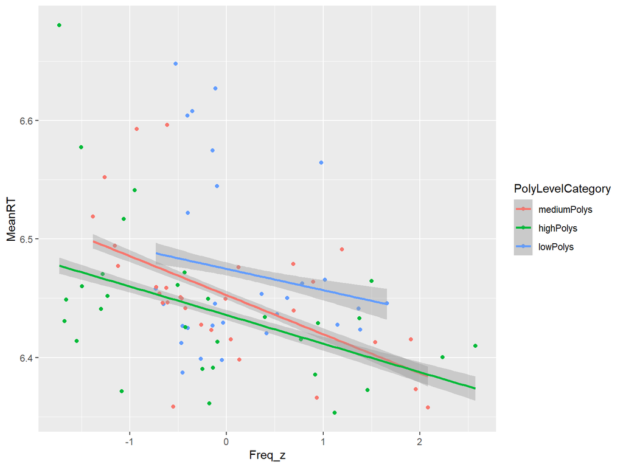

```r
ggplot(nouns_by_item, aes(x = Freq_z, y = MeanRT, colour = PolyLevelCategory)) +
  geom_point() +
  geom_smooth(method = "lm", se = TRUE)
```

## MODEL WITHOUT INTERACTION

```r
lm3 = lm(MeanRT ~ PolyLevelCategory + Freq_z, data = nouns_by_item)

summary(lm3)
```

```
##
## Call:
## lm(formula = MeanRT ~ PolyLevelCategory + Freq_z, data = nouns_by_item)
##
## Residuals:
##      Min       1Q   Median       3Q      Max
## -0.10847 -0.03714 -0.01412  0.02485  0.19973
##
## Coefficients:
##                             Estimate Std. Error  t value Pr(>|t|)
## (Intercept)                 6.452580   0.002238 2883.099  < 2e-16 ***
## PolyLevelCategoryhighPolys -0.017080   0.003174   -5.382 8.21e-08 ***
## PolyLevelCategorylowPolys   0.023539   0.003209    7.334 3.18e-13 ***
## Freq_z                     -0.026081   0.001314  -19.846  < 2e-16 ***
## ---
## Signif. codes:  0 '***' 0.001 '**' 0.01 '*' 0.05 '.' 0.1 ' ' 1
##
## Residual standard error: 0.05938 on 2075 degrees of freedom
## Multiple R-squared:  0.1929, Adjusted R-squared:  0.1917
## F-statistic: 165.3 on 3 and 2075 DF,  p-value: < 2.2e-16
```

## The intercept is again mapped onto the zero levels of both predictors

- Which means PolyLevelCategory = 0 (i.e. “mediumPolys”/“medium”) and Freq_z = 0
- Each subsequent coefficient shows us what happens to the DV when we move one step along the x-axis in terms of the corresponding predictor

| Coefficients | Estimate |
| --- | --- |
| (Intercept) | 6.452580 |
| PolyLevelCategoryhighPolys | -0.017080 |
| PolyLevelCategorylowPolys | 0.023539 |
| Freq_z | -0.026081 |

- Regression line equation for the medium polysemy level:

  ```
      + MeanRT ~ 6.452580 - 0.026081 * Freq_z
  ```

- Regression line equation for the high polysemy level:

  ```
      + MeanRT ~ 6.452580 - 0.017080 -0.026081 * Freq_z
  ```

- Regression line equation for the low polysemy level:

  ```
      + MeanRT ~ 6.452580 + 0.023539 - 0.026081 * Freq_z
  ```

## MODEL WITH INTERACTION

```r
lm4 = lm(MeanRT ~ PolyLevelCategory * Freq_z, data = nouns_by_item)

summary(lm4)
```

```
##
## Call:
## lm(formula = MeanRT ~ PolyLevelCategory * Freq_z, data = nouns_by_item)
##
## Residuals:
##      Min       1Q   Median       3Q      Max
## -0.11229 -0.03465 -0.01480  0.02540  0.20288
##
## Coefficients:
##                                    Estimate Std. Error  t value Pr(>|t|)
## (Intercept)                        6.452608   0.002230 2892.948  < 2e-16 ***
## PolyLevelCategoryhighPolys        -0.016785   0.003169   -5.297 1.30e-07 ***
## PolyLevelCategorylowPolys          0.022182   0.003238    6.850 9.72e-12 ***
## Freq_z                            -0.032942   0.002273  -14.493  < 2e-16 ***
## PolyLevelCategoryhighPolys:Freq_z  0.008873   0.002915    3.044  0.00236 **
## PolyLevelCategorylowPolys:Freq_z   0.014983   0.004048    3.701  0.00022 ***
## ---
## Signif. codes:  0 '***' 0.001 '**' 0.01 '*' 0.05 '.' 0.1 ' ' 1
##
## Residual standard error: 0.05918 on 2073 degrees of freedom
## Multiple R-squared:  0.1991, Adjusted R-squared:  0.1972
## F-statistic: 103.1 on 5 and 2073 DF,  p-value: < 2.2e-16
```

## Interpreting the coefficients

| Coefficients | Estimate |  |
| --- | --- | --- |
| (Intercept) | 6.452608 | zero levels of all predictors |
| PolyLevelCategoryhighPolys | -0.016785 | difference between mediumPolys and highPolys when Freq_z=0 |
| PolyLevelCategorylowPolys | 0.022182 | difference between mediumPolys and lowPolys when Freq_z=0 |
| Freq_z | -0.032942 | slope of the Freq_z effect when PolyLevelCategory=0 (mediumPolys) |
| PolyLevelCategoryhighPolys:Freq_z | 0.008873 | correction to the Freq_z slope for PolyLevelCategory highPolys |
| PolyLevelCategorylowPolys:Freq_z | 0.014983 | correction to the Freq_z slope for PolyLevelCategory lowPolys |

- Regression line equation for the mediumPolys level:

  ```
      + MeanRT = 6.452608 - 0.032942 * Freq_z
  ```

- Regression line equation for the highPolys level:

  ```
      + MeanRT = (6.452608 - 0.016785) + (-0.032942 + 0.008873) * Freq_z
  ```

- Regression line equation for the Polysemy “lowPolys” (“low”) level:

  ```
      + MeanRT = (6.452608 + 0.022182) + (-0.032942 + 0.014983) * Freq_z
  ```

## THE CASE OF AN INTERACTION BETWEEN TWO CATEGORICAL PREDICTORS

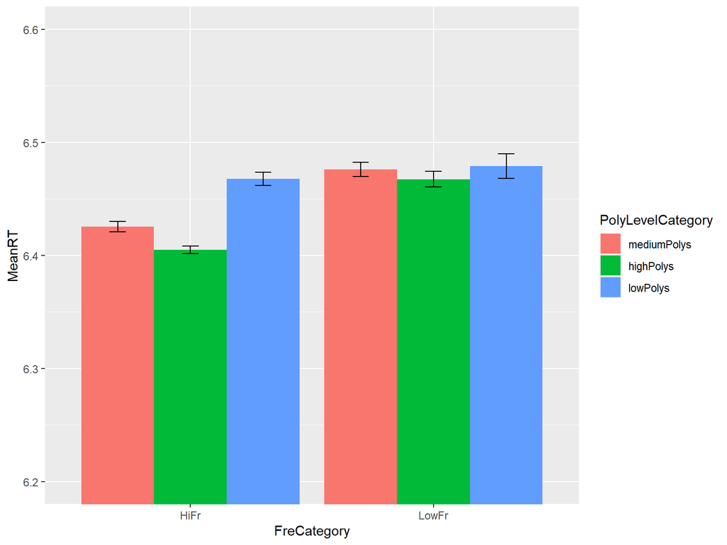

```r
ggplot(nouns_by_item, aes(x=FreCategory, y=MeanRT, fill=PolyLevelCategory)) +
  coord_cartesian(ylim = c(6.2, 6.6)) +
  stat_summary(fun = mean, geom = "bar", position = "dodge") +
  stat_summary(fun.data = mean_cl_normal, geom = "errorbar", position = position_dodge(width = 0.90), width = 0.2)
```

## LET’S BUILD THE MODEL

```r
lm5 = lm(MeanRT ~ PolyLevelCategory * FreCategory, data = nouns_by_item)

summary(lm5)
```

```
##
## Call:
## lm(formula = MeanRT ~ PolyLevelCategory * FreCategory, data = nouns_by_item)
##
## Residuals:
##      Min       1Q   Median       3Q      Max
## -0.11759 -0.03825 -0.01681  0.02414  0.21302
##
## Coefficients:
##                                              Estimate Std. Error  t value
## (Intercept)                                  6.425396   0.003334 1927.254
## PolyLevelCategoryhighPolys                  -0.020544   0.004779   -4.299
## PolyLevelCategorylowPolys                    0.042138   0.004445    9.481
## FreCategoryLowFr                             0.050694   0.004562   11.112
## PolyLevelCategoryhighPolys:FreCategoryLowFr  0.011779   0.006468    1.821
## PolyLevelCategorylowPolys:FreCategoryLowFr  -0.039086   0.006636   -5.890
##                                             Pr(>|t|)
## (Intercept)                                  < 2e-16 ***
## PolyLevelCategoryhighPolys                  1.80e-05 ***
## PolyLevelCategorylowPolys                    < 2e-16 ***
## FreCategoryLowFr                             < 2e-16 ***
## PolyLevelCategoryhighPolys:FreCategoryLowFr   0.0687 .
## PolyLevelCategorylowPolys:FreCategoryLowFr  4.49e-09 ***
## ---
## Signif. codes:  0 '***' 0.001 '**' 0.01 '*' 0.05 '.' 0.1 ' ' 1
##
## Residual standard error: 0.06038 on 2073 degrees of freedom
## Multiple R-squared:  0.1663, Adjusted R-squared:  0.1643
## F-statistic:  82.7 on 5 and 2073 DF,  p-value: < 2.2e-16
```

## INTERPRETING THE COEFFICIENTS

| Coefficients | Estimate |  |
| --- | --- | --- |
| (Intercept) | 6.425396 | zero level of all predictors (mediumPolys, HighFr) |
| PolyLevelCategoryhighPolys | -0.020544 | difference between mediumPolys_HighFr and highPolys_HighwFr |
| PolyLevelCategorylowPolys | 0.042138 | difference between mediumPolys_HighFr and lowPolys_HighwFr |
| FreCategoryLowFr | 0.050694 | difference between mediumPolys_HihgFr and mediumPolys_lowFr |
| PolyLevelCategoryhighPolys:FreCategoryLowFr | 0.011779 | additional correction for highPolys_LowFr beyond the difference between mediumPolys_HighFr and highPolys_HighwFr and the difference between mediumPolys_HihgFr and mediumPolys_lowFr |
| PolyLevelCategorylowPolys:FreCategoryLowFr | -0.039086 | additional correction for lowPolys_LowFr beyond the difference between mediumPolys_HighFr and lowPolys_HighwFr and the difference between mediumPolys_HihgFr and mediumPolys_lowFr |

- How we compute the group averages from the coefficients:

| Group | Average based on the coefficients |
| --- | --- |
| medium, HF: | 6.425396 |
| high, HF: | 6.425396 - 0.020544 = 6.404852 |
| low, HF: | 6.425396 + 0.042138 = 6.467534 |
| medium, LF: | 6.425396 + 0.050694 = 6.47609 |
| high, LF: | 6.425396 - 0.020544 + 0.050694 + 0.011779 = 6.467325 |
| low, LF: | 6.425396 + 0.042138 + 0.050694 - 0.039086 = 6.479142 |

memdium = mediumPolys, low = lowPolys, high = highPolys LF = low frequency, HF = high frequency

- Let’s check the calculation:

```r
with(nouns_by_item, tapply(MeanRT, list(PolyLevelCategory, FreCategory), mean))
```

```
##                 HiFr    LowFr
## mediumPolys 6.425396 6.476090
## highPolys   6.404852 6.467324
## lowPolys    6.467534 6.479142
```

## THE CASE OF AN INTERACTION BETWEEN TWO CONTINUOUS PREDICTORS

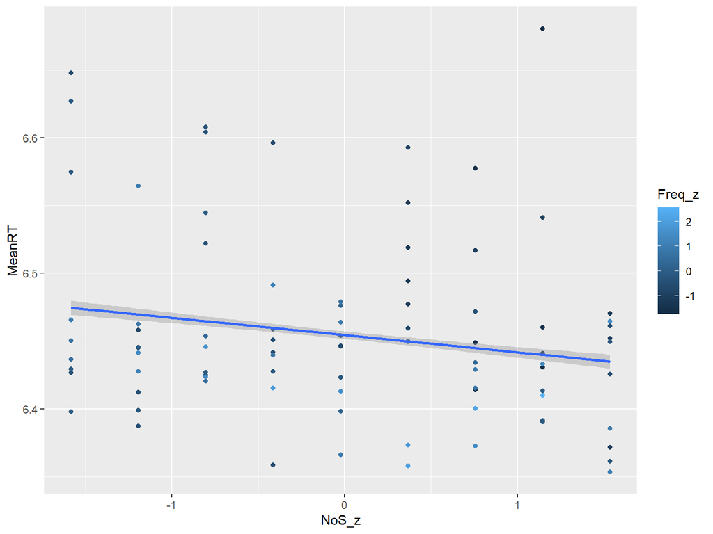

```r
ggplot(nouns_by_item, aes(x=NoS_z, y=MeanRT, colour = Freq_z)) +
  geom_point() +
  geom_smooth(method = "lm", se = TRUE)
```

## LET’S BUILD THE MODEL

```r
lm6 = lm(MeanRT ~ NoS_z * Freq_z, data = nouns_by_item)

summary(lm6)
```

```
##
## Call:
## lm(formula = MeanRT ~ NoS_z * Freq_z, data = nouns_by_item)
##
## Residuals:
##      Min       1Q   Median       3Q      Max
## -0.11549 -0.03779 -0.01318  0.01932  0.19613
##
## Coefficients:
##               Estimate Std. Error  t value Pr(>|t|)
## (Intercept)   6.454012   0.001321 4884.974   <2e-16 ***
## NoS_z        -0.016357   0.001317  -12.417   <2e-16 ***
## Freq_z       -0.025088   0.001470  -17.071   <2e-16 ***
## NoS_z:Freq_z -0.002804   0.001565   -1.792   0.0733 .
## ---
## Signif. codes:  0 '***' 0.001 '**' 0.01 '*' 0.05 '.' 0.1 ' ' 1
##
## Residual standard error: 0.05937 on 2075 degrees of freedom
## Multiple R-squared:  0.1931, Adjusted R-squared:  0.192
## F-statistic: 165.5 on 3 and 2075 DF,  p-value: < 2.2e-16
```

## INTERPRETING THE COEFFICIENTS

| Coefficients | Estimate |  |
| --- | --- | --- |
| (Intercept) | 6.454012 | RT when NoS_z = 0 and Freq_z = 0 (both mapped onto the average) |
| NoS_z | -0.016357 | slope for NoS_z when Freq_z = 0 |
| Freq_z | -0.025088 | slope for Freq_z when NoS_z = 0 |
| NoS_z:Freq_z | -0.002804 | how much the NoS_z slope needs to be corrected if we move one unit along the Freq_z scale, i.e. how much the Freq_z slope needs to be corrected if we move one unit along the NoS_z scale. |

- THE EASIEST WAY TO SEE WHAT’S HAPPENING IS TO PLOT AN INTERACTION LIKE THIS (if it’s significant)

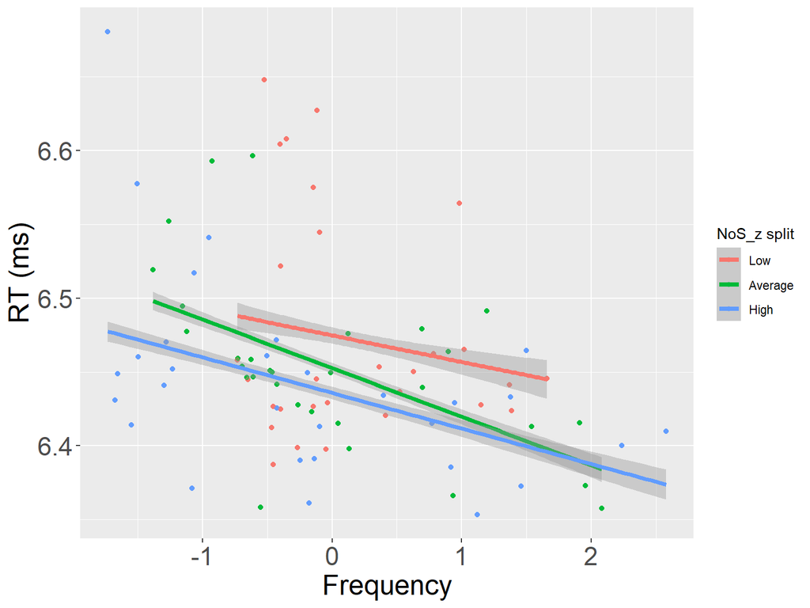

```r
nouns_by_item$seckano <- cut_interval(nouns_by_item$NoS_z, 3)

ggplot(nouns_by_item, aes(Freq_z, MeanRT, colour=seckano)) +
  geom_point(alpha=0.3) +
  scale_colour_discrete(name  ="NoS_z split", labels=c("Low", "Average", "High"))+
  xlab("Frequency") + ylab("RT (ms)") +
  theme(axis.text=element_text(size=18),axis.title=element_text(size=20))+
  stat_smooth(method = lm, formula = y ~ x, size = 1.5)
```

## THAT’S ENOUGH ABOUT COEFFICIENTS, LETS GO BACK TO MIXED EFFECTS

- In the next session: random effects